# ST2195 Coursework Q5 - R

## **Use the available variables to construct a model that predicts delays**

#### **Load libraries**

```r
library(DBI)
library(tidyverse)
library(mlr3)
library(mlr3learners)
library(mlr3pipelines)
library(mlr3tuning)
library(mlr3viz)
```

Open connection to the database

```r
conn <- dbConnect(RSQLite::SQLite(), "flights.db")

flight_data <- tbl(conn, "flight_data")
```

Majority of the data preparation has been done during the earlier stages of the analysis.

#### **Overview of Delays**

```r
flight_data %>%
  group_by(DepDel15) %>%
  count(ArrDel15)
```

| DepDel15 | ArrDel15 | n |
| --- | --- | --- |
| 0 | 0 | 23974289 |
| 0 | 1 | 2272590 |
| 1 | 0 | 908481 |
| 1 | 1 | 4649375 |

There is a positive relationship between `DepDel15` and `ArrDel15`. Intuitively, delay in arrivals increases when delays on departure increase. Hence, departure delay is a factor in determining arrival delays.

#### **Arrival Delay for Unique Carrier**

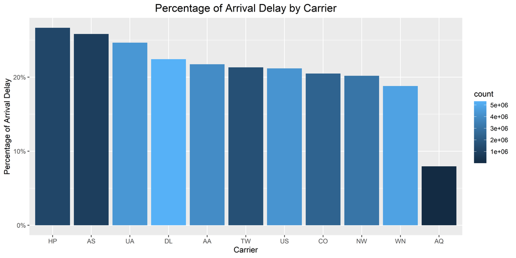

```r
flight_data %>%
  group_by(UniqueCarrier) %>%
  summarise(per_del = mean(ArrDel15),
            count = n()) %>%
  arrange(desc(per_del)) %>%
  ggplot(aes(x = reorder(UniqueCarrier, -per_del), y = per_del)) +
  geom_bar(stat = "identity", aes(fill = count)) +
  labs(title = "Percentage of Arrival Delay by Carrier",
       x = "Carrier",
       y = "Percentage of Arrival Delay") +
  theme_grey() +
  theme(plot.title = element_text(size = 15, hjust = 0.5)) +
  scale_y_continuous(labels = scales::percent)
```

There is no obvious trend between the number of flights and arrival delays. However, by observation, some carriers (darker colored) have a higher percentage of arrival delays even though they rank lower in terms of number of flights. Thus, carrier might be a factor in determining arrival delays.

#### **Correlation Analysis**

Before proceeding to the modeling stage:

Check for correlation between the numerical variables of the model data

```r
corr_data <- dbGetQuery(conn,
                        "SELECT Year, Month, DayofMonth, DayOfWeek, DepTime, CRSDepTime,
                        ArrTime, CrsArrTime, FlightNum, ActualElapsedTime, CRSElapsedTime,
                        AirTime, ArrDelay, DepDelay, Distance, TaxiIn, TaxiOut, DepDel15,
                        ArrDel15
                        FROM flight_data
                        WHERE Distance IS NOT NULL")

corr_matrix <- round(cor(corr_data), 2)

corr_matrix <- corr_matrix %>%
  as.data.frame()

corr_matrix %>%
  kableExtra::kbl() %>%
  kableExtra::kable_styling(bootstrap_options = c("striped", "condensed"),
                            font_size = 7)
```

|  | Year | Month | DayofMonth | DayOfWeek | DepTime | CRSDepTime | ArrTime | CRSArrTime | FlightNum | ActualElapsedTime | CRSElapsedTime | AirTime | ArrDelay | DepDelay | Distance | TaxiIn | TaxiOut | DepDel15 | ArrDel15 |
| --- | --- | --- | --- | --- | --- | --- | --- | --- | --- | --- | --- | --- | --- | --- | --- | --- | --- | --- | --- |
| Year | 1.00 | 0.01 | 0.00 | 0.00 | 0.00 | 0.01 | -0.01 | 0.00 | 0.09 | 0.06 | 0.06 | 0.05 | 0.02 | 0.02 | 0.04 | 0.06 | 0.08 | 0.03 | 0.02 |
| Month | 0.01 | 1.00 | 0.00 | 0.00 | 0.00 | -0.01 | 0.00 | -0.01 | 0.01 | 0.01 | 0.01 | 0.00 | -0.01 | -0.01 | 0.01 | 0.02 | 0.01 | 0.00 | -0.01 |
| DayofMonth | 0.00 | 0.00 | 1.00 | 0.00 | 0.00 | 0.02 | 0.00 | 0.02 | 0.00 | 0.00 | 0.00 | 0.00 | 0.01 | 0.01 | 0.00 | 0.00 | 0.00 | 0.01 | 0.01 |
| DayOfWeek | 0.00 | 0.00 | 0.00 | 1.00 | 0.01 | 0.01 | 0.01 | 0.01 | 0.01 | 0.01 | 0.01 | 0.01 | 0.00 | 0.02 | 0.01 | 0.01 | -0.02 | 0.02 | 0.01 |
| DepTime | 0.00 | 0.00 | 0.00 | 0.01 | 1.00 | 0.90 | 0.71 | 0.71 | 0.01 | -0.03 | -0.03 | -0.04 | 0.16 | 0.17 | -0.04 | -0.02 | 0.06 | 0.20 | 0.16 |
| CRSDepTime | 0.01 | -0.01 | 0.02 | 0.01 | 0.90 | 1.00 | 0.64 | 0.80 | 0.00 | -0.06 | -0.06 | -0.06 | 0.11 | 0.12 | -0.06 | -0.04 | 0.04 | 0.15 | 0.12 |
| ArrTime | -0.01 | 0.00 | 0.00 | 0.01 | 0.71 | 0.64 | 1.00 | 0.81 | 0.00 | 0.04 | 0.04 | 0.03 | 0.07 | 0.07 | 0.03 | 0.03 | 0.08 | 0.13 | 0.11 |
| CRSArrTime | 0.00 | -0.01 | 0.02 | 0.01 | 0.71 | 0.80 | 0.81 | 1.00 | -0.01 | 0.01 | 0.01 | 0.01 | 0.10 | 0.11 | 0.01 | 0.00 | 0.06 | 0.13 | 0.11 |
| FlightNum | 0.09 | 0.01 | 0.00 | 0.01 | 0.01 | 0.00 | 0.00 | -0.01 | 1.00 | -0.14 | -0.14 | -0.15 | 0.01 | 0.00 | -0.15 | 0.01 | -0.01 | 0.00 | 0.00 |
| ActualElapsedTime | 0.06 | 0.01 | 0.00 | 0.01 | -0.03 | -0.06 | 0.04 | 0.01 | -0.14 | 1.00 | 0.98 | 0.99 | 0.09 | 0.03 | 0.97 | 0.22 | 0.34 | 0.02 | 0.12 |
| CRSElapsedTime | 0.06 | 0.01 | 0.00 | 0.01 | -0.03 | -0.06 | 0.04 | 0.01 | -0.14 | 0.98 | 1.00 | 0.99 | 0.00 | 0.03 | 0.99 | 0.18 | 0.23 | 0.02 | 0.05 |
| AirTime | 0.05 | 0.00 | 0.00 | 0.01 | -0.04 | -0.06 | 0.03 | 0.01 | -0.15 | 0.99 | 0.99 | 1.00 | 0.04 | 0.02 | 0.98 | 0.16 | 0.20 | 0.01 | 0.08 |
| ArrDelay | 0.02 | -0.01 | 0.01 | 0.00 | 0.16 | 0.11 | 0.07 | 0.10 | 0.01 | 0.09 | 0.00 | 0.04 | 1.00 | 0.84 | 0.00 | 0.10 | 0.32 | 0.62 | 0.67 |
| DepDelay | 0.02 | -0.01 | 0.01 | 0.02 | 0.17 | 0.12 | 0.07 | 0.11 | 0.00 | 0.03 | 0.03 | 0.02 | 0.84 | 1.00 | 0.02 | 0.00 | 0.07 | 0.63 | 0.52 |
| Distance | 0.04 | 0.01 | 0.00 | 0.01 | -0.04 | -0.06 | 0.03 | 0.01 | -0.15 | 0.97 | 0.99 | 0.98 | 0.00 | 0.02 | 1.00 | 0.15 | 0.20 | 0.01 | 0.05 |
| TaxiIn | 0.06 | 0.02 | 0.00 | 0.01 | -0.02 | -0.04 | 0.03 | 0.00 | 0.01 | 0.22 | 0.18 | 0.16 | 0.10 | 0.00 | 0.15 | 1.00 | 0.07 | -0.02 | 0.09 |
| TaxiOut | 0.08 | 0.01 | 0.00 | -0.02 | 0.06 | 0.04 | 0.08 | 0.06 | -0.01 | 0.34 | 0.23 | 0.20 | 0.32 | 0.07 | 0.20 | 0.07 | 1.00 | 0.08 | 0.29 |
| DepDel15 | 0.03 | 0.00 | 0.01 | 0.02 | 0.20 | 0.15 | 0.13 | 0.13 | 0.00 | 0.02 | 0.02 | 0.01 | 0.62 | 0.63 | 0.01 | -0.02 | 0.08 | 1.00 | 0.69 |
| ArrDel15 | 0.02 | -0.01 | 0.01 | 0.01 | 0.16 | 0.12 | 0.11 | 0.11 | 0.00 | 0.12 | 0.05 | 0.08 | 0.67 | 0.52 | 0.05 | 0.09 | 0.29 | 0.69 | 1.00 |

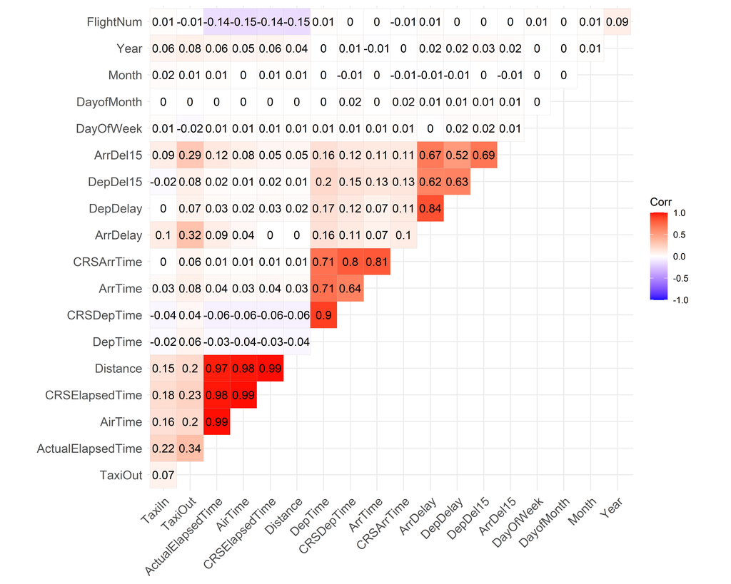

```r
corr_matrix %>%
  ggcorrplot::ggcorrplot(hc.order = TRUE,
                         type = "upper",
                         lab = TRUE,
                         lab_size = 4)
```

#### **Data Modeling**

`features`: The list of variables that might be meaningful factors in determining delays

```r
features <- c("season", "UniqueCarrier", "DepTime", "DepDel15",
              "ActualElapsedTime", "Distance", "TaxiOut", "ArrDel15")

model_data <- flight_data %>%
  filter(Year == 2000) %>%
  select(all_of(features)) %>%
  collect()

glimpse(model_data)
```

```
## Rows: 5,481,303
## Columns: 8
## $ season            <chr> "Winter", "Winter", "Winter", "Winter", "Winter", "W~
## $ UniqueCarrier     <chr> "HP", "HP", "HP", "HP", "HP", "HP", "HP", "HP", "HP"~
## $ DepTime           <int> 1647, 1648, 1645, 842, 849, 844, 1702, 1658, 1656, 1~
## $ DepDel15          <dbl> 0, 0, 0, 0, 0, 0, 0, 0, 0, 1, 0, 0, 0, 1, 0, 0, 0, 0~
## $ ActualElapsedTime <int> 259, 291, 247, 255, 299, 277, 250, 243, 266, 275, 23~
## $ Distance          <int> 1587, 1587, 1587, 1587, 1587, 1587, 1587, 1587, 1587~
## $ TaxiOut           <int> 11, 47, 14, 8, 24, 27, 13, 7, 20, 38, 10, 11, 13, 12~
## $ ArrDel15          <dbl> 0, 1, 0, 0, 1, 1, 0, 0, 0, 1, 0, 0, 0, 1, 0, 0, 0, 0~
```

Convert to factors where required

```r
model_data$season <- factor(model_data$season, ordered = TRUE,
                            levels = c("Winter", "Spring", "Summer", "Autumn"))
model_data$UniqueCarrier <- factor(model_data$UniqueCarrier)
model_data$ArrDel15 <- factor(model_data$ArrDel15)
model_data$DepDel15 <- factor(model_data$DepDel15)

str(model_data)
```

```
## tibble [5,481,303 x 8] (S3: tbl_df/tbl/data.frame)
##  $ season           : Ord.factor w/ 4 levels "Winter"<"Spring"<..: 1 1 1 1 1 1 1 1 1 1 ...
##  $ UniqueCarrier    : Factor w/ 11 levels "AA","AQ","AS",..: 6 6 6 6 6 6 6 6 6 6 ...
##  $ DepTime          : int [1:5481303] 1647 1648 1645 842 849 844 1702 1658 1656 1955 ...
##  $ DepDel15         : Factor w/ 2 levels "0","1": 1 1 1 1 1 1 1 1 1 2 ...
##  $ ActualElapsedTime: int [1:5481303] 259 291 247 255 299 277 250 243 266 275 ...
##  $ Distance         : int [1:5481303] 1587 1587 1587 1587 1587 1587 1587 1587 1587 1587 ...
##  $ TaxiOut          : int [1:5481303] 11 47 14 8 24 27 13 7 20 38 ...
##  $ ArrDel15         : Factor w/ 2 levels "0","1": 1 2 1 1 2 2 1 1 1 2 ...
```

Get the training and test sets

```r
n <- nrow(model_data)

train_set <- sample(n, round(0.5*n))

test_set <- setdiff(1:n, train_set)
```

#### **Set up task**

```r
task <- TaskClassif$new('flight_delay', backend=model_data, target = 'ArrDel15')

measure <- msr('classif.ce')

print(task)
```

```
## <TaskClassif:flight_delay> (5481303 x 8)
## * Target: ArrDel15
## * Properties: twoclass
## * Features (7):
##   - int (4): ActualElapsedTime, DepTime, Distance, TaxiOut
##   - fct (2): DepDel15, UniqueCarrier
##   - ord (1): season
```

Some of the variables are factor for which some models do not support

Convert them to numerical values (The following will be used later)

```r
fencoder <- po("encode", method = "treatment",
  affect_columns = selector_type("factor"))
ord_to_int <- po("colapply", applicator = as.integer,
  affect_columns = selector_type("ordered"))
```

#### **Logistic Regression**

```r
learner_lr <- lrn("classif.log_reg")
gc_lr <- po('imputemean') %>>%
  po(learner_lr)
glrn_lr <- GraphLearner$new(gc_lr)

glrn_lr$train(task, row_ids = train_set)
glrn_lr$predict(task, row_ids = test_set)$score()
```

```
## classif.ce
## 0.08650645
```

#### **Gradient Boosting**

```r
learner_gb <- lrn("classif.xgboost")
gc_gb <- po('imputemean') %>>%
  fencoder %>>% ord_to_int %>>%
  po(learner_gb)
glrn_gb <- GraphLearner$new(gc_gb)

glrn_gb$train(task, row_ids = train_set)

glrn_gb$predict(task, row_ids = test_set)$score()
```

```
## classif.ce
## 0.09039568
```

#### **Classification Trees**

```r
learner_tree <- lrn("classif.rpart")

gc_tree <- po('imputemean') %>>%
  po(learner_tree)
glrn_tree <- GraphLearner$new(gc_tree)

glrn_tree$train(task, row_ids = train_set)
glrn_tree$predict(task, row_ids = test_set)$score()
```

```
## classif.ce
## 0.09431664
```

#### **Construct benchmark design and run comparisons**

Set up seed for reproducible results

```r
set.seed(121)

lrn_list <- list(
  glrn_lr,
  glrn_gb,
  glrn_tree
)

bm_design <- benchmark_grid(task = task, resamplings = rsmp('cv', folds = 3),
                            learners = lrn_list)

bmr <- benchmark(bm_design, store_models = TRUE)
```

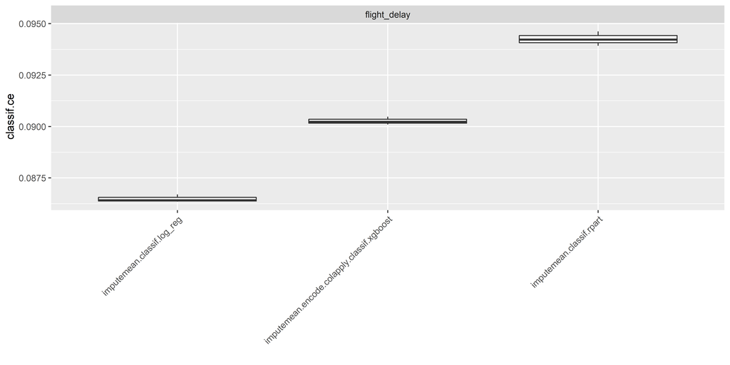

```r
autoplot(bmr) +
  theme(axis.text.x = element_text(angle = 45, hjust = 1))
```

```r
bmr$aggregate(measure) %>%
  kableExtra::kbl() %>%
  kableExtra::kable_styling(bootstrap_options = c("striped", "condensed"),
                            full_width = TRUE)
```

| nr | resample_result | task_id | learner_id | resampling_id | iters | classif.ce |
| --- | --- | --- | --- | --- | --- | --- |
| 1 | <environment: 0x00000000490b5890> | flight_delay | imputemean.classif.log_reg | cv | 3 | 0.0864856 |
| 2 | <environment: 0x000000004907c770> | flight_delay | imputemean.encode.colapply.classif.xgboost | cv | 3 | 0.0902674 |
| 3 | <environment: 0x000000004904e098> | flight_delay | imputemean.classif.rpart | cv | 3 | 0.0942570 |

The baseline algorithm selected is Logistic Regression due to its simplicity and speed. The other two algorithms were selected for comparison.

Overall, the three models have similar distribution in errors. But `log_reg` has the lowest error in predicting delays. Hence, `log_reg` is the better model out of the three.

```r
dbDisconnect(conn)
```